# Relationships between Loan Characteristics and Chance of Default

## by Ryan Johnson

## Investigation Overview

> In this investigation, I wanted to look at why loans tended to default. The main focus was on LoanStatus, which had several designations, which I combined into Default or Current. Meaning the loan was either current, or in some form of default. All complete loans were dropped. This was then compared against several different categories, such as, ProsperScore, LoanAmount, BorrowerAPR and ListingCategory.

## Dataset Overview

> The original data set consisted of 113,937 loans which was later brought down to 72,555 loans that were still active(not complete). LoanStatus was then compared to several different categories to see if a trend exists as to why loans default.

## LoanStatus Breakdown

> Here we can see what the break down of the differing loan statuses are. We can see a strong indication the most loans are current, and a large percentage of loans are complete. Thats why we end up droping those records later. Later we will combine Defaulted, Chargedoff, and Cancelled into the Category Defaulted, and Current, FinalPaymentInProgress as Current.

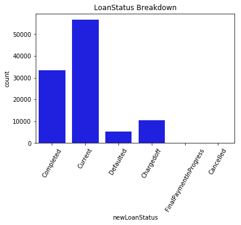

```python
g = sns.countplot(loans['newLoanStatus'], color='blue')
plt.title('LoanStatus Breakdown')
plt.xticks(rotation=60);
```

## Loans Issued by ProsperScore

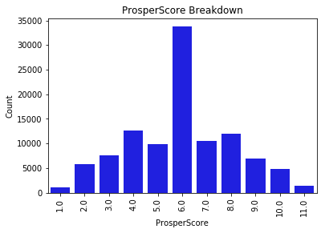

```python
g = sns.barplot(x=loans.ProsperScore.value_counts().index, y=loans.ProsperScore.value_counts(), color='blue')
plt.title('ProsperScore Breakdown')
plt.xlabel('ProsperScore')
plt.ylabel('Count')
plt.xticks(rotation=90);
```

## Loans Issued by OriginalLoanAmount

> The distribution of loans is Right Skewed as you'd expect, larger loans are harder to get. We can see loans of all different values have been issued, however, we can see several main dollar amounts tend to pop up on $5k increments.

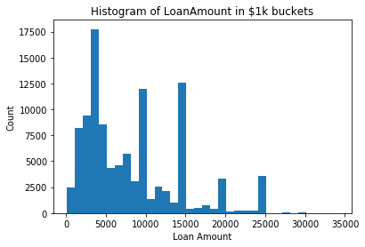

```python
la = plt.hist(loans['LoanOriginalAmount'], bins=np.arange(100,35000,1000))
plt.xlabel('Loan Amount')
plt.ylabel('Count')
plt.title('Histogram of LoanAmount in $1k buckets');
```

## Loans Issued by OriginalLoanAmount

> Loans of all different values have been issued, however, we can see several man dollar amounts tend to pop up on $5k increments

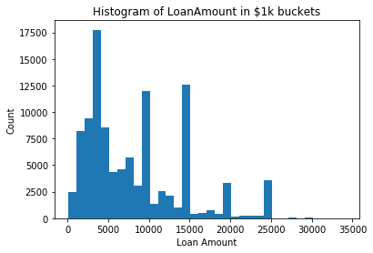

```python
la = plt.hist(loans['LoanOriginalAmount'], bins=np.arange(100,35000,1000))
plt.xlabel('Loan Amount')
plt.ylabel('Count')
plt.title('Histogram of LoanAmount in $1k buckets');
```

#### 77.9 percent of active loans are not in a default status, leaving the remaining 22.1% deliquent. Lets look into where some of these deliquent loans are coming from.

## LoanStatus by ListingCategory

> Loans taken out for Personal, Student, or where the use was Unknown were 100% in default status. This would tell me, loans of those types are very risky to fund. Where loans for RV's and Motorcycles are much more likely to be current.

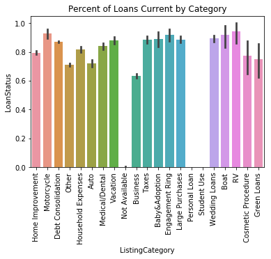

```python
sns.barplot(x='ListingCategory', y='LoanStatus', data=loans_default)
plt.title('Percent of Loans Current by Category')
plt.xticks(rotation=90);
```

## LoanStatus by ProsperScore

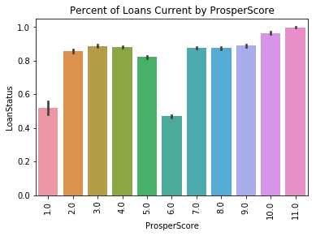

```python
sns.barplot(x='ProsperScore', y='LoanStatus', data=loans_default)
plt.title('Percent of Loans Current by ProsperScore')
plt.xticks(rotation=90);
```

## LoanStatus in Relation to LoanAmount and Borrower APR

> In these charts we can see that we have a larger number of loans in the smaller loan amounts <5k that are in default then current. And loans that are current seem to have a higher freq of loans in the 10k and 15k range then loans that are in default. The same can be said for BorrowerAPR, loans that have a higher rate, more risky, tend to default more often, then those with a lower APR.

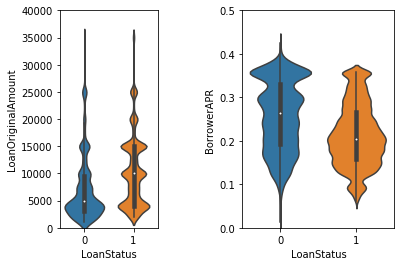

```python
fig = plt.figure()
ax1 = fig.add_subplot(131)
sns.violinplot(x='LoanStatus', y='LoanOriginalAmount', data=loans_default).set_ylim([0,40000])

ax2 = fig.add_subplot(122)
sns.violinplot(x='LoanStatus', y='BorrowerAPR', data=loans_default).set_ylim([0,.50]);
```

## Sankey Diagram of Score to Status to ListingCategory.

> I find this diagram to show a nice representation of loans. Here we can see that the largest number of loans tend to come from ProsperScores of 6, And if we follow the split we can see that over 53% of them are in Default. We can then see of the loans in default that 40% of them were for Debt Consolidation. As an investor, you might want to invest in loans that aren't for Debt Consolidation.

```python
%%html
<img src="sankey.png" />
```

[figure not shown]